**Trial biostatistics toolkit**

OperationsBiostatisticsFull library

# Safety Review Committee packet: Study CP-101, Cohort 4

A worked example on synthetic data. Study CP-101 does not exist, and this is not a study document.

Prepared

25 October 2026

**Synthetic data, worked example.** Every number below is computed from the TRIALMON synthetic dataset by the same R functions that drive the TRIALMON console. In a real study the tables a committee relies on come from validated programs on ADaM; this packet was not produced by a validated system, and no one has signed it. The packet presents data. It makes no recommendation: the committee adjudicates and decides, and records its decision in the minutes.

| Item | Detail |
| --- | --- |
| Study | CP-101 (synthetic): first-in-human, multiple ascending dose, open label for illustration |
| Design | Once-daily oral dosing, Days 1 to 28 (the DLT window); follow-up to Day 43 |
| Data cut | After the last Cohort 4 participant completed the DLT window (Day 29) |
| Cohorts dosed | C1 10 mg (n=3), C2 30 mg (n=3), C3 60 mg (n=6), C4 120 mg (n=6); 18 participants dosed. Cohort 5 (200 mg) is planned and not dosed. |
| Settings (SAP parameters) | MedDRA v29.1; NCI CTCAE v6.0 for lab grades (AE grades as recorded, v6.0); potential Hy’s Law window 30 days; ALP < 2x ULN convention off |
| Status | Draft for committee review. Rendered from synthetic data; not a validated output. |

# Questions for the committee

1. **Adjudicate a candidate DLT.** CP101-018 (Cohort 4, 120 mg) had QTcF 503 ms on Day 22 (baseline 462 ms). Under the synthetic protocol, QTcF above 500 ms is a candidate DLT; the event has not been adjudicated (Sections 5 and 9).
2. **Review the liver findings.** CP101-014 (an adjudicated DLT) meets the potential Hy’s Law screen; CP101-004 and CP101-009 had ALT or AST above 3x ULN that needed confirmation (Section 4).
3. **Decide the next step for dose escalation** from the options the protocol allows (Section 9). No option is recommended here.

# Cohort summary

| Cohort | Dose (mg) | Status | Dosed | DLT-evaluable | Stopped treatment | Any TEAE | Grade 3 or higher TEAE | Serious AE | Related or possibly related TEAE |
| --- | --- | --- | --- | --- | --- | --- | --- | --- | --- |
| C1 | 10 | Complete | 3 | 3 | 0 | 2 (67%) | 0 (0%) | 0 (0%) | 1 (33%) |
| C2 | 30 | Complete | 3 | 3 | 0 | 3 (100%) | 0 (0%) | 0 (0%) | 3 (100%) |
| C3 | 60 | Complete | 6 | 6 | 0 | 6 (100%) | 1 (17%) | 0 (0%) | 4 (67%) |
| C4 | 120 | DLT window complete; follow-up ongoing | 6 | 6 | 1 | 6 (100%) | 2 (33%) | 1 (17%) | 4 (67%) |
| C5 | 200 | Planned; not dosed | 0 | 0 | 0 | 0 | 0 | 0 | 0 |

Participants counted once per column. TEAE: treatment-emergent adverse event. AE grades as recorded by the investigator (NCI CTCAE v6.0). DLT-evaluable: completed the 28-day DLT window or had a DLT. Synthetic data.

# Dose-limiting toxicities

| Cohort | Dose (mg) | Dosed | DLT-evaluable | Confirmed DLTs | Pending adjudication |
| --- | --- | --- | --- | --- | --- |
| C1 | 10 | 3 | 3 | 0 | 0 |
| C2 | 30 | 3 | 3 | 0 | 0 |
| C3 | 60 | 6 | 6 | 1 | 0 |
| C4 | 120 | 6 | 6 | 1 | 1 |
| C5 | 200 | 0 | 0 | 0 | 0 |

DLTs and candidate DLTs

| Participant | Cohort | Dose (mg) | Status | Event |
| --- | --- | --- | --- | --- |
| CP101-008 | C3 | 60 | Adjudicated DLT | Platelet count decreased, grade 3 (Day 15) |
| CP101-014 | C4 | 120 | Adjudicated DLT | Liver injury: potential Hy’s Law (Day 22) |
| CP101-018 | C4 | 120 | Pending adjudication | QTcF 503 ms on Day 22 (candidate DLT; adjudication pending) |

# Liver tests

**Definition used.** A participant is a *potential Hy’s Law* case when ALT or AST is at least 3x ULN and total bilirubin (TBL) is above 2x ULN **on or after** the day of that aminotransferase elevation, within 30 days of it (the window is an SAP convention). Every draw with ALT or AST at least 3x ULN opens its own window, so a second elevation weeks after the first is screened as well; the tables report the first draw that qualifies. ALP is shown but not used to exclude a case; the SAP option ALP < 2x ULN is off. This follows FDA, *Drug-Induced Liver Injury: Premarketing Clinical Evaluation* (July 2009), which asks for TBL above 2x ULN “without initial findings of cholestasis (elevated serum ALP)” and for other causes to be ruled out. The screen cannot rule out other causes; the medical monitor does. Separately, any ALT or AST **above** 3x ULN calls for repeat ALT, AST, ALP and TBL within 48 to 72 hours to confirm it.

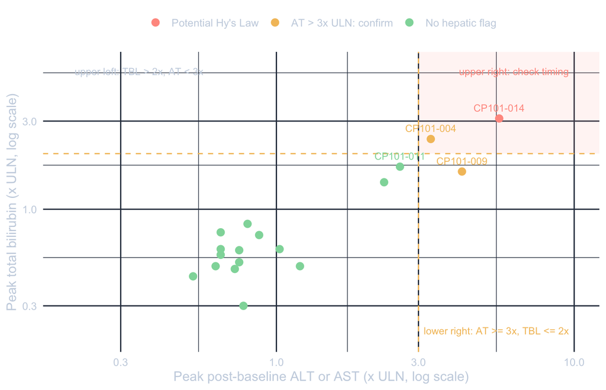

eDISH: each point is one participant’s peak post-baseline ALT or AST against peak TBL. The peaks need not come from the same draw, so the upper-right quadrant is a prompt to check timing, not a classification. Lower right: aminotransferase elevation without TBL above 2x ULN. Upper left: TBL above 2x ULN without an aminotransferase elevation (cholestasis, Gilbert syndrome or other causes).

Participants with ALT or AST above 3x ULN, or in the upper-right quadrant

| Participant | Cohort | Peak ALT / AST (x ULN) | ALT or AST >= 3x (day) | ALP then (x ULN) | R ratio (pattern) | Peak TBL (x ULN) | TBL > 2x on or after it (day) | Potential Hy’s Law | Quadrant |
| --- | --- | --- | --- | --- | --- | --- | --- | --- | --- |
| CP101-014 | C4 | 5.6 / 4.9 | 15 | 1.1 | 4.0 (mixed) | 3.1 | 22 | Yes | Upper right |
| CP101-004 | C2 | 3.3 / 2.4 | 22 | 0.8 | 4.1 (mixed) | 2.4 |  | No | Upper right |
| CP101-009 | C3 | 4.2 / 3.6 | 15 | 1.2 | 3.5 (mixed) | 1.6 |  | No | Lower right |

Confirmation of aminotransferase elevations above 3x ULN

| Participant | ALT or AST > 3x ULN (day) | Value (x ULN) | First full repeat panel (day) | Days later | Within 48 to 72 h | Repeat ALT or AST (x ULN) | FDA (2009) discontinuation consideration |
| --- | --- | --- | --- | --- | --- | --- | --- |
| CP101-004 | 22 | 3.3 | 24 | 2 | Yes | 2.6 |  |
| CP101-009 | 15 | 4.2 | 20 | 5 | No | 3.4 |  |
| CP101-014 | 15 | 4.4 | 17 | 2 | Yes | 5.1 | ALT or AST > 3x ULN with TBL > 2x ULN in the same draw |

ALT or AST >= 3x (day): for a potential Hy’s Law case, the draw that opens the qualifying window; otherwise the first such draw. ALP and the R ratio are read from that draw. R ratio = (ALT/ULN)/(ALP/ULN) (at the first draw with ALT at least 3x ULN if only AST reached 3x in that draw): 5 or more hepatocellular, between 2 and 5 mixed, 2 or less cholestatic. “Within 48 to 72 h” is judged on study days (the data carry days, not clock times), as 3 days or fewer. The FDA (2009) discontinuation considerations that these data can show are ALT or AST above 8x ULN, above 5x ULN for more than 2 weeks, and above 3x ULN with TBL above 2x ULN; INR and symptoms are not in these data.

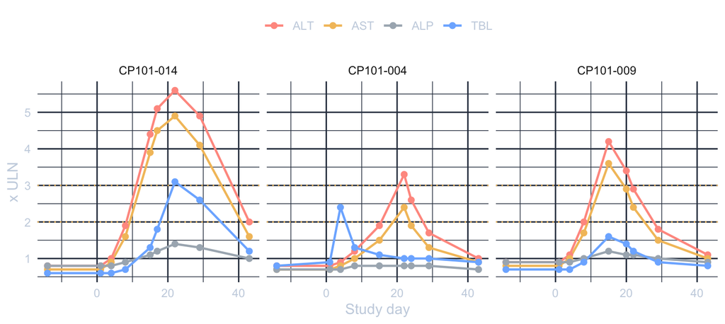

# QTcF

Participants by maximum post-baseline QTcF category

| Category | C1 (N=3) | C2 (N=3) | C3 (N=6) | C4 (N=6) | Total (N=18) |
| --- | --- | --- | --- | --- | --- |
| QTcF > 450 ms | 0 (0%) | 1 (33%) | 2 (33%) | 1 (17%) | 4 (22%) |
| QTcF > 480 ms | 0 (0%) | 1 (33%) | 0 (0%) | 1 (17%) | 2 (11%) |
| QTcF > 500 ms | 0 (0%) | 0 (0%) | 0 (0%) | 1 (17%) | 1 (6%) |
| Change from baseline > 30 ms | 0 (0%) | 1 (33%) | 0 (0%) | 1 (17%) | 2 (11%) |
| Change from baseline > 60 ms | 0 (0%) | 0 (0%) | 0 (0%) | 0 (0%) | 0 (0%) |
| Baseline QTcF > 450 ms | 0 (0%) | 1 (33%) | 0 (0%) | 1 (17%) | 2 (11%) |

Participants in any category

| Participant | Cohort | Baseline (ms) | Maximum (ms) | Day | Maximum change (ms) | Screen |
| --- | --- | --- | --- | --- | --- | --- |
| CP101-006 | C2 | 453 | 486 | 15 | 33 | AMBER |
| CP101-011 | C3 | 448 | 474 | 22 | 26 | watch |
| CP101-012 | C3 | 446 | 468 | 15 | 22 | watch |
| CP101-018 | C4 | 462 | 503 | 22 | 41 | RED |

QTcF: Fridericia-corrected QT, triplicate mean. Categories per ICH E14 (May 2005), the E14 Q&A (R3) (December 2015) and the E14/S7B Q&As (February 2022): maximum post-baseline value above 450, 480 and 500 ms, regardless of sex, and maximum increase from baseline above 30 and 60 ms. Categories are cumulative and a value equal to a threshold is not above it. Baseline: Day 1 predose; post-baseline values start at the Day 1 4 h post-dose ECG. Participants already above 450 ms at baseline: 2 of 18. A categorical summary is a screen; concentration-QTc modeling belongs in a prespecified analysis.

# Laboratory shifts

Shift from baseline grade to worst post-baseline grade

| Test | Baseline grade | N | Worst grade 0 | 1 | 2 | 3 | 4 |
| --- | --- | --- | --- | --- | --- | --- | --- |
| Alanine aminotransferase increased | 0 | 18 | 11 | 4 | 2 | 1 | 0 |
| Aspartate aminotransferase increased | 0 | 18 | 13 | 3 | 2 | 0 | 0 |
| Blood bilirubin increased | 0 | 18 | 13 | 1 | 3 | 1 | 0 |
| Alkaline phosphatase increased | 0 | 18 | 15 | 3 | 0 | 0 | 0 |
| Creatinine increased | 0 | 18 | 16 | 1 | 1 | 0 | 0 |
| Anemia | 0 | 18 | 17 | 1 | 0 | 0 | 0 |
| Neutrophil count decreased | 0 | 18 | 17 | 0 | 1 | 0 | 0 |
| Thrombocytopenia | 0 | 18 | 17 | 0 | 0 | 1 | 0 |

Worst post-baseline grade 3 or higher

| Participant | Test | Baseline grade | Worst grade |
| --- | --- | --- | --- |
| CP101-014 | Alanine aminotransferase increased | 0 | 3 |
| CP101-014 | Blood bilirubin increased | 0 | 3 |
| CP101-008 | Thrombocytopenia | 0 | 3 |

Lab grades: NCI CTCAE v6.0. Grades come from multiples of the ULN or LLN, or from fold over baseline where the term says so, not from absolute values alone. Creatinine increased: under v6.0, fold over baseline applies only when the baseline is below the LLN; under v5.0 the grade is the worse of the x ULN and fold-over-baseline grades. The v6.0 cut points follow admiral 1.5.0 (`atoxgr_criteria_ctcv6`) and were not re-checked against the NCI v6.0 workbook here; v5.0 follows the NCI v5.0 workbook (2017-11-27). Baseline grades use reference-range criteria only. Hemoglobin grade 4 is a clinical judgment and is not derived from the value.

# Adverse events by SOC and preferred term

Treatment-emergent adverse events, participants

| System organ class / Preferred term | C1 (N=3) | C2 (N=3) | C3 (N=6) | C4 (N=6) | Total (N=18) |
| --- | --- | --- | --- | --- | --- |
| Any TEAE | 2 (67%) | 3 (100%) | 6 (100%) | 6 (100%) | 17 (94%) |
| Investigations | 0 (0%) | 2 (67%) | 2 (33%) | 3 (50%) | 7 (39%) |
| Alanine aminotransferase increased | 0 (0%) | 1 (33%) | 1 (17%) | 1 (17%) | 3 (17%) |
| Electrocardiogram QT prolonged | 0 (0%) | 1 (33%) | 0 (0%) | 1 (17%) | 2 (11%) |
| Aspartate aminotransferase increased | 0 (0%) | 0 (0%) | 0 (0%) | 1 (17%) | 1 (6%) |
| Blood bilirubin increased | 0 (0%) | 1 (33%) | 0 (0%) | 0 (0%) | 1 (6%) |
| Neutrophil count decreased | 0 (0%) | 0 (0%) | 0 (0%) | 1 (17%) | 1 (6%) |
| Platelet count decreased | 0 (0%) | 0 (0%) | 1 (17%) | 0 (0%) | 1 (6%) |
| Gastrointestinal disorders | 1 (33%) | 1 (33%) | 2 (33%) | 2 (33%) | 6 (33%) |
| Nausea | 1 (33%) | 0 (0%) | 2 (33%) | 1 (17%) | 4 (22%) |
| Diarrhoea | 0 (0%) | 1 (33%) | 0 (0%) | 1 (17%) | 2 (11%) |
| Nervous system disorders | 1 (33%) | 1 (33%) | 1 (17%) | 3 (50%) | 6 (33%) |
| Headache | 1 (33%) | 1 (33%) | 1 (17%) | 1 (17%) | 4 (22%) |
| Dizziness | 0 (0%) | 0 (0%) | 0 (0%) | 2 (33%) | 2 (11%) |
| General disorders and administration site conditions | 0 (0%) | 0 (0%) | 1 (17%) | 1 (17%) | 2 (11%) |
| Fatigue | 0 (0%) | 0 (0%) | 1 (17%) | 1 (17%) | 2 (11%) |
| Blood and lymphatic system disorders | 0 (0%) | 0 (0%) | 1 (17%) | 0 (0%) | 1 (6%) |
| Anaemia | 0 (0%) | 0 (0%) | 1 (17%) | 0 (0%) | 1 (6%) |
| Hepatobiliary disorders | 0 (0%) | 0 (0%) | 0 (0%) | 1 (17%) | 1 (6%) |
| Hyperbilirubinaemia | 0 (0%) | 0 (0%) | 0 (0%) | 1 (17%) | 1 (6%) |

Serious adverse events

| Participant | Preferred term | SOC | Grade | Relationship | Onset (day) | Outcome |
| --- | --- | --- | --- | --- | --- | --- |
| CP101-014 | Hyperbilirubinaemia | Hepatobiliary disorders | 3 | Related | 22 | ongoing |

Adverse events coded with MedDRA v29.1 (primary SOC). AE grades as recorded by the investigator (NCI CTCAE v6.0); they are data and are not re-derived when the lab-grading version (v6.0 here) changes. Participants are counted once per row; N is the number dosed in each cohort. SOCs and preferred terms are sorted by the total number of participants. Preferred terms keep MedDRA’s spelling.

# Study-level indicators

| Indicator | Value | Level | Range | Detail | Source |
| --- | --- | --- | --- | --- | --- |
| Participants with a treatment-emergent SAE (trial-level acceptable range) | 5.6 % of dosed | GREEN | AMBER > 10, RED > 20 | 1 of 18 dosed participants | computed from ADAE / ADLB |
| Scheduled safety-lab visits with no labs | 0.7 % of visits | GREEN | AMBER > 2, RED > 5 | 1 of 141 scheduled visits | computed from ADAE / ADLB |
| Screen-failure rate | 30.8 % | AMBER | AMBER > 30, RED > 40 | 8 of 26 screened did not meet eligibility (plan: 25%) | operational feed (synthetic) |
| Enrollment versus plan | -22 % vs plan | AMBER | AMBER < -15, RED < -30 | 18 dosed against 23 planned by this date | operational feed (synthetic) |
| Open queries older than 30 days | 14 queries | AMBER | AMBER > 10, RED > 25 | backlog rising ahead of the C4 data cut | operational feed (synthetic) |
| Important protocol deviations per dosed participant | 0.11 per participant | GREEN | AMBER > 0.2, RED > 0.4 | 2 important deviations in 18 dosed participants | operational feed (synthetic) |
| Median days from visit to data entry | 2 days | GREEN | AMBER > 5, RED > 10 | entry within plan | operational feed (synthetic) |

Pre-specified acceptable ranges, as in ICH E6(R3) section 3.10.1.3 (“quality tolerance limits at the trial level”): exceeding one triggers evaluation, not an automatic stop. The operational values are synthetic. Every level in this packet rolls up worst-of: the participant and cohort tier is RED and the study tier is AMBER, so the overall screen is RED.

# Dose escalation: data for the decision

Key findings by dose

| Dose (mg) | Cohort | DLT-evaluable | DLTs (confirmed + pending) | Potential Hy’s Law | ALT or AST > 3x ULN | QTcF > 500 ms or change > 60 ms | Grade 3 or higher TEAE |
| --- | --- | --- | --- | --- | --- | --- | --- |
| 10 | C1 | 3 | 0 + 0 | 0 | 0 | 0 | 0 (0%) |
| 30 | C2 | 3 | 0 + 0 | 0 | 1 | 0 | 0 (0%) |
| 60 | C3 | 6 | 1 + 0 | 0 | 1 | 0 | 1 (17%) |
| 120 | C4 | 6 | 1 + 1 | 1 | 1 | 1 | 2 (33%) |

Participants. Potential Hy’s Law: window 30 days, ALP option off. Grade 3 or higher TEAE counts AE grades as recorded by the investigator (NCI CTCAE v6.0).

What an illustrative 3+3 rule would say (a reference, not a recommendation)

| Cohort | Dose (mg) | Illustrative 3+3 rule reference |
| --- | --- | --- |
| C1 | 10 | 0 of 3: escalation-eligible under the rule |
| C2 | 30 | 0 of 3: escalation-eligible under the rule |
| C3 | 60 | 1 of 6: escalation-eligible under the rule |
| C4 | 120 | 1 of 6 confirmed, 1 pending adjudication. If not a DLT: 1 of 6, escalation-eligible under the rule. If a DLT: 2 of 6, under the rule, the dose exceeds the MTD |

**Reading the rule reference.** Under a 3+3 rule, 0 of 3 or 1 of 6 participants with a DLT is escalation-eligible, 1 of 3 means the cohort expands to 6, and 2 or more mean the dose exceeds the maximum tolerated dose; a dose can be called the MTD only with 6 participants treated at it. For Cohort 4 the reference depends on the committee’s adjudication of CP101-018. 3+3 appears here only as an illustration: model-assisted designs such as BOIN (FDA fit-for-purpose determination, December 2021, for the local BOIN design under a non-informative prior) are the current alternative, and this example implements neither as a decision tool. A rule reference never replaces the committee’s review of the whole safety picture, including the potential Hy’s Law case at 120 mg.

**Options the synthetic protocol allows the committee to consider,** in protocol order: escalate to 200 mg as planned; escalate to an intermediate dose; enroll further participants at 120 mg; stop escalation and select a lower dose; pause dosing pending further evaluation. They are listed, not ranked.

**Committee record** (completed by the committee, not by this packet)

DLT adjudication for CP101-018: ______________________________

Decision on dose escalation: ______________________________

Rationale: ______________________________

Chair: ______________________ Date: ______________________

# Methods and conventions

- **Source.** The TRIALMON synthetic dataset (`adsl`, `adlb`, `adeg`, `adae`, `cohorts`, `study_kri`), written by `R/gen_data.R` from one seed. Every table is computed at render time by `R/logic.R`, the code behind the TRIALMON console and its tests, and the findings the text cites (participants, values, days and counts) are computed from the same objects. The study design and the protocol’s options are fixed text from the synthetic protocol.
- **Populations.** Safety population: all dosed participants. Baseline: the Day 1 predose value. Post-baseline: labs after Day 1; ECGs from the Day 1 4 h post-dose time point on; both include unscheduled draws.
- **Counting.** Participants are counted once per row of a table. Percentages use the dosed participants in the column.
- **Dictionaries and grading.** MedDRA v29.1; NCI CTCAE v6.0 for laboratory grades, derived from the values; AE grades as recorded by the investigator under NCI CTCAE v6.0 (a property of the data: changing the lab-grading version does not re-grade an AE). All three are parameters of this document (`meddra_version`, `ctcae_version`, `ae_ctcae_version`), as are the Hy’s Law window (`hys_window_days`) and the ALP convention (`alp_convention`).
- **Guidance cited.** FDA, *Drug-Induced Liver Injury: Premarketing Clinical Evaluation* (July 2009); ICH E14 (May 2005), E14 Q&A (R3) (10 Dec 2015) and E14/S7B Q&As (Step 4 21 Feb 2022); NCI CTCAE v6.0; ICH E6(R3) (Step 4 6 Jan 2025; EU effective 23 Jul 2025; FDA final guidance Sep 2025); Annex 2 Step 4 3 Jun 2026 (CHMP 25 Jun 2026, EU effective 15 Jan 2027; FDA: draft guidance Dec 2024, not final).
- **What was executed.** Rendered with Quarto and R version 4.6.0 (2026-04-24) on synthetic data; the rules are covered by testthat tests (rule boundaries, the shipped study and the Shiny server). No validated system or independent programmer produced or checked these numbers.
- **What a real packet adds.** Tables from validated programs on ADaM, a named statistician’s sign-off, and, for a DSMB with access to unblinded comparisons, open and closed sections with an independent reporting statistician. This open-label example has no closed section.